# Modeling and prediction for movies

## Setup

### LOAD packages

```r
library(ggplot2)
library(dplyr)
library(statsr)
library(GGally)
```

### Load data

```r
load("movies.Rdata")
```

## Part 1: Data

This data set deals with the attributes of movies.This set has data about how much audiences and critics like the movies as well as numerous other variables about the movies and information from Rotten Tomatoes and IMDB for a random sample of movies.The data set is comprised of 651 randomly sampled movies produced and released before 2016.Each row represents a movies and answer some informational characteristics about them.

**As random sampling was used to collect the data so we can generalize the data for a bigger population.**

**But we can not do a casual inference because there has been no random assisgnment during the colllection of data.**

## Part 2: Research question

Here the given data is a collection of information and rating both imdb and rotten tomatoes for 651 movies those were released before 2016. From this data set I want to find out a linear regression model that fits for the IMDB ratings for a movie. Here my response variable will be IMDB ratings. I want know about the characteristics that make a movies more likely to get a better rating on IMDB. I will be using the existing variables on the given dataset to answer the question without making any new ones.

## Part 3: Exploratory data analysis

Here as the exploratory data analysis I will see the relationship of variables critics_score, audience_score, best_pic_nom, best_pic_win , best_actor_win, best_actress_win, best_dir_win, top200_box, director with response variable imdb_rating.

I did not chose variables relating to the url, catagorical info about actors and DVD release/ theatre release date because these clearly do not seem to have any relation with imdb rating.

Here **I will use linear modeling and their residual plots to determine linearity**. **Then I will use corelation co-efficient for examining any colinear relationship.**

After this I will chose my secondary variables for modeling.

### Section A: **Linearity Check**

Here I will examine the linear relations of variables genre, critics_score, audience_score,best_pic_nom,best_pic_win, best_actor_win, best_actress_win, best_dir_win, top200_box with imdb_ratings one by one with help of histogram and residual plots.

**(1)** We examine relations between imdb_ratings and critics_score.

```r
 critics_lm <- lm(formula = imdb_rating ~ critics_score, data = movies)

summary(critics_lm)
```

```
##
## Call:
## lm(formula = imdb_rating ~ critics_score, data = movies)
##
## Residuals:
##      Min       1Q   Median       3Q      Max
## -2.93679 -0.39499  0.04512  0.43875  2.47556
##
## Coefficients:
##                Estimate Std. Error t value Pr(>|t|)
## (Intercept)   4.8075715  0.0620690   77.45   <2e-16 ***
## critics_score 0.0292177  0.0009654   30.26   <2e-16 ***
## ---
## Signif. codes:  0 '***' 0.001 '**' 0.01 '*' 0.05 '.' 0.1 ' ' 1
##
## Residual standard error: 0.6991 on 649 degrees of freedom
## Multiple R-squared:  0.5853, Adjusted R-squared:  0.5846
## F-statistic: 915.9 on 1 and 649 DF,  p-value: < 2.2e-16
```

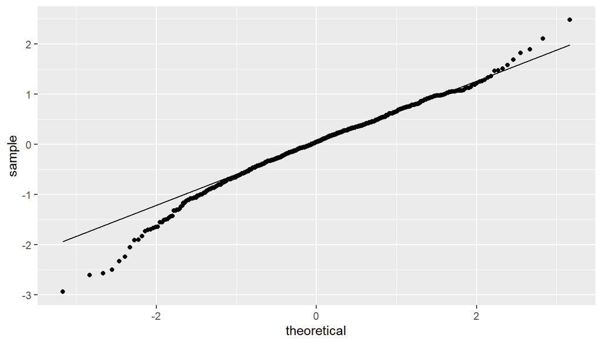

```r
ggplot(data = critics_lm, aes(sample = .resid)) + stat_qq() + stat_qq_line()
```

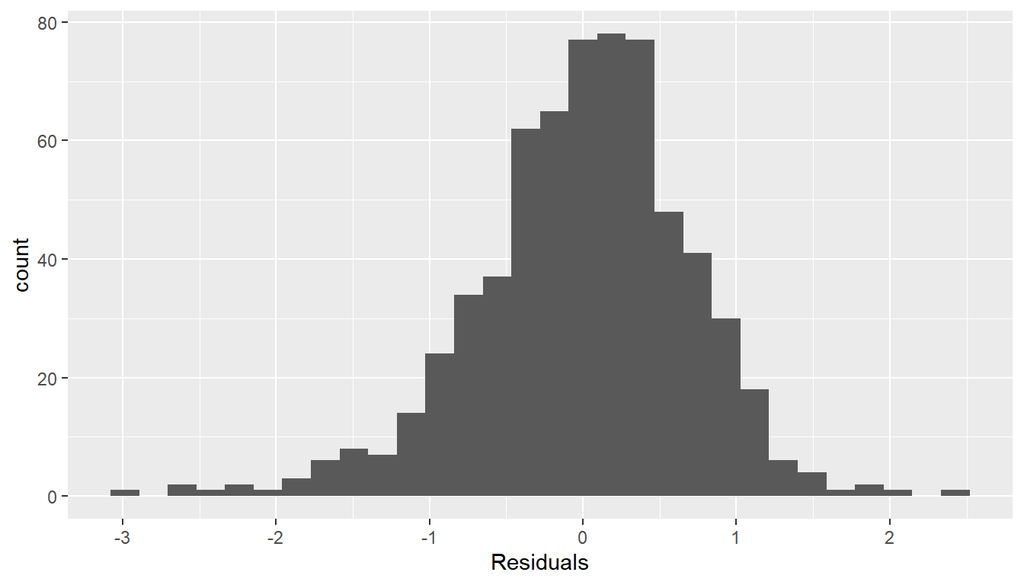

```r
ggplot(data = critics_lm, aes(x = .resid)) +
  geom_histogram() +
  xlab("Residuals")
```

Summary of this linear model shows a high adjusted R square. Also the residual distribution is nearly normal around zero. From this we can see linear relation between these two variables.

**(2)** We examine relations between imdb_ratings and audience_score.

```r
audience_lm <- lm(formula = imdb_rating ~ audience_score, data = movies)

summary(audience_lm)
```

```
##
## Call:
## lm(formula = imdb_rating ~ audience_score, data = movies)
##
## Residuals:
##     Min      1Q  Median      3Q     Max
## -3.2082 -0.1866  0.0712  0.3093  1.1516
##
## Coefficients:
##                Estimate Std. Error t value Pr(>|t|)
## (Intercept)    3.599992   0.069291   51.95   <2e-16 ***
## audience_score 0.046392   0.001057   43.89   <2e-16 ***
## ---
## Signif. codes:  0 '***' 0.001 '**' 0.01 '*' 0.05 '.' 0.1 ' ' 1
##
## Residual standard error: 0.545 on 649 degrees of freedom
## Multiple R-squared:  0.748,  Adjusted R-squared:  0.7476
## F-statistic:  1926 on 1 and 649 DF,  p-value: < 2.2e-16
```

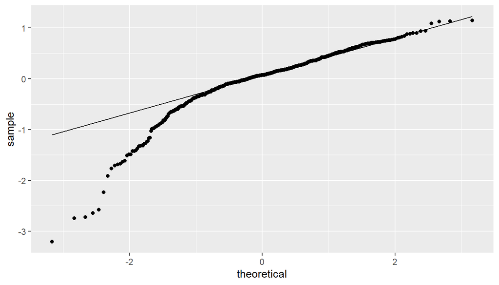

```r
ggplot(data = audience_lm, aes(sample = .resid)) + stat_qq() + stat_qq_line()
```

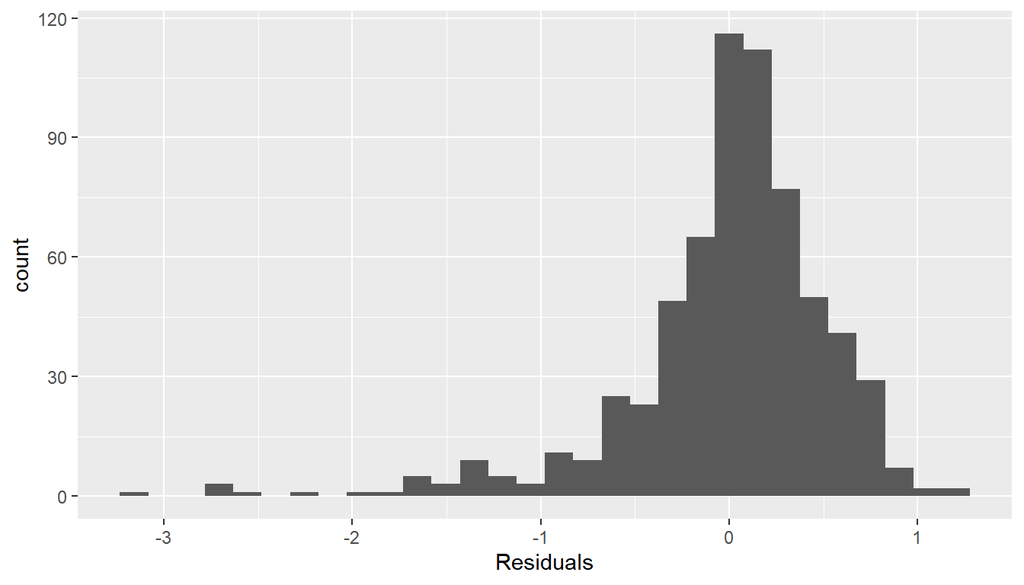

```r
ggplot(data = audience_lm, aes(x = .resid)) +
  geom_histogram() +
  xlab("Residuals")
```

Summary of this linear model shows a high adjusted R square. But the residual distribution is nearly normal around zero (slightly left skewed). From this we can see a weak linear relation between these two variables.

**(3)** We examine relations between imdb_ratings and best_pic_nom.

```r
best_pic_nom_lm <- lm(formula = imdb_rating ~ best_pic_nom, data = movies)

summary(best_pic_nom_lm)
```

```
##
## Call:
## lm(formula = imdb_rating ~ best_pic_nom, data = movies)
##
## Residuals:
##     Min      1Q  Median      3Q     Max
## -4.5491 -0.5491  0.0509  0.7509  2.0509
##
## Coefficients:
##                 Estimate Std. Error t value Pr(>|t|)
## (Intercept)      6.44913    0.04225  152.62  < 2e-16 ***
## best_pic_nomyes  1.30087    0.22986    5.66 2.28e-08 ***
## ---
## Signif. codes:  0 '***' 0.001 '**' 0.01 '*' 0.05 '.' 0.1 ' ' 1
##
## Residual standard error: 1.06 on 649 degrees of freedom
## Multiple R-squared:  0.04703,    Adjusted R-squared:  0.04556
## F-statistic: 32.03 on 1 and 649 DF,  p-value: 2.279e-08
```

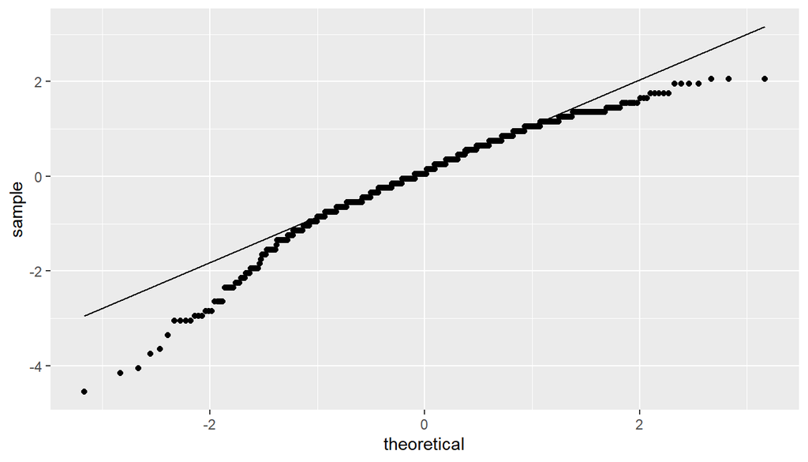

```r
ggplot(data = best_pic_nom_lm, aes(sample = .resid)) + stat_qq() + stat_qq_line()
```

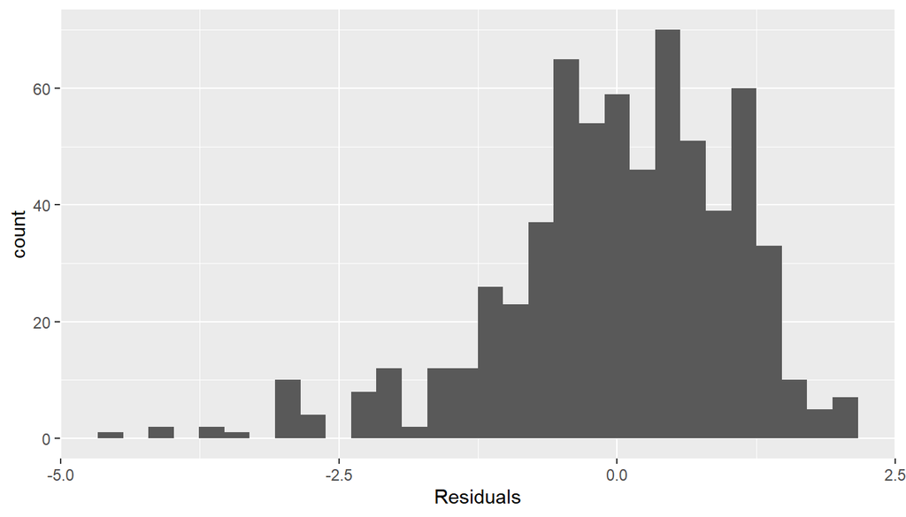

```r
ggplot(data = best_pic_nom_lm, aes(x = .resid)) +
  geom_histogram() +
  xlab("Residuals")
```

Summary of this linear model shows a low adjusted R square. The residual distribution is nearly normal around zero. From this we can see linear relation between these two variables.

**(4)** We examine relations between imdb_ratings and best_pic_win.

```r
best_pic_win_lm <- lm(formula = imdb_rating ~ best_pic_win, data = movies)

summary(best_pic_win_lm)
```

```
##
## Call:
## lm(formula = imdb_rating ~ best_pic_win, data = movies)
##
## Residuals:
##     Min      1Q  Median      3Q     Max
## -4.5778 -0.5778  0.1222  0.8222  2.0222
##
## Coefficients:
##                 Estimate Std. Error t value Pr(>|t|)
## (Intercept)      6.47780    0.04238 152.834  < 2e-16 ***
## best_pic_winyes  1.42220    0.40874   3.479 0.000536 ***
## ---
## Signif. codes:  0 '***' 0.001 '**' 0.01 '*' 0.05 '.' 0.1 ' ' 1
##
## Residual standard error: 1.076 on 649 degrees of freedom
## Multiple R-squared:  0.01831,    Adjusted R-squared:  0.0168
## F-statistic: 12.11 on 1 and 649 DF,  p-value: 0.000536
```

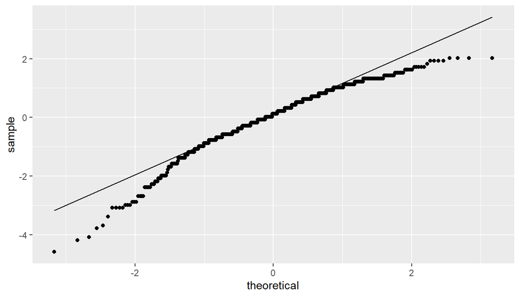

```r
ggplot(data = best_pic_win_lm, aes(sample = .resid)) + stat_qq() + stat_qq_line()
```

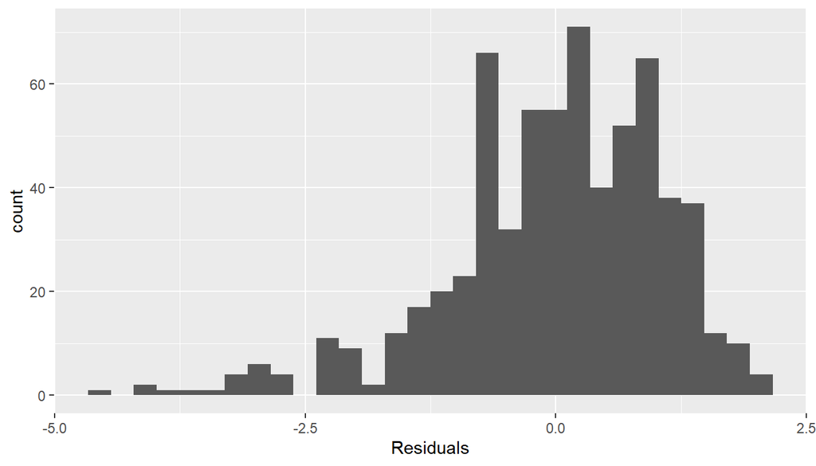

```r
ggplot(data = best_pic_win_lm, aes(x = .resid)) +
  geom_histogram() +
  xlab("Residuals")
```

Summary of this linear model shows a low adjusted R square. BUt the residual distribution is nearly normal around zero. From this we can see a linear relation between these two variables.

**(5)** We examine relations between imdb_ratings and best_actor_win.

```r
best_actor_win_lm <- lm(formula = imdb_rating ~ best_actor_win, data = movies)

summary(best_actor_win_lm)
```

```
##
## Call:
## lm(formula = imdb_rating ~ best_actor_win, data = movies)
##
## Residuals:
##     Min      1Q  Median      3Q     Max
## -4.5645 -0.5645  0.0355  0.8355  2.3355
##
## Coefficients:
##                   Estimate Std. Error t value Pr(>|t|)
## (Intercept)        6.46452    0.04586 140.961   <2e-16 ***
## best_actor_winyes  0.20000    0.12134   1.648   0.0998 .
## ---
## Signif. codes:  0 '***' 0.001 '**' 0.01 '*' 0.05 '.' 0.1 ' ' 1
##
## Residual standard error: 1.083 on 649 degrees of freedom
## Multiple R-squared:  0.004169,   Adjusted R-squared:  0.002635
## F-statistic: 2.717 on 1 and 649 DF,  p-value: 0.09977
```

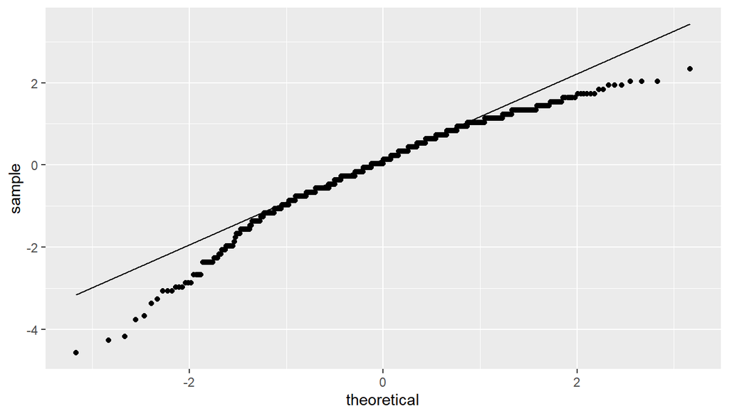

```r
ggplot(data = best_actor_win_lm, aes(sample = .resid)) + stat_qq() + stat_qq_line()
```

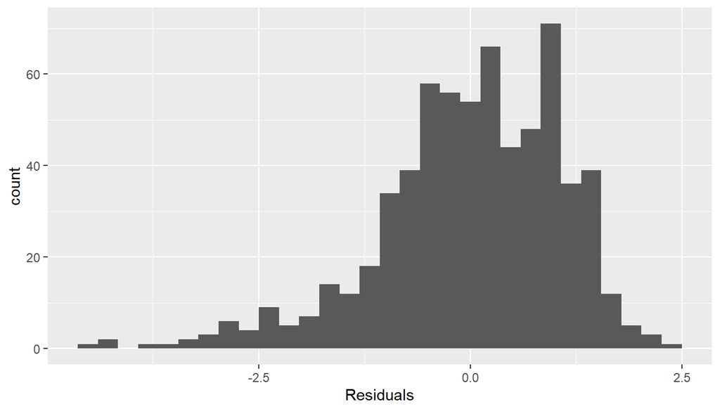

```r
ggplot(data = best_actor_win_lm, aes(x = .resid)) +
  geom_histogram() +
  xlab("Residuals")
```

Summary of this linear model shows a low adjusted R square. The residual distribution is nearly normal around zero but it lacks constant variance. From this we can see a very weak linear relation between these two variables.

**(6)** We examine relations between imdb_ratings and best_actress_win.

```r
best_actress_win_lm <- lm(formula = imdb_rating ~ best_actress_win, data = movies)

summary(best_actress_win_lm)
```

```
##
## Call:
## lm(formula = imdb_rating ~ best_actress_win, data = movies)
##
## Residuals:
##     Min      1Q  Median      3Q     Max
## -4.5658 -0.5658  0.1342  0.8342  2.2875
##
## Coefficients:
##                     Estimate Std. Error t value Pr(>|t|)
## (Intercept)           6.4658     0.0450 143.684   <2e-16 ***
## best_actress_winyes   0.2467     0.1353   1.823   0.0687 .
## ---
## Signif. codes:  0 '***' 0.001 '**' 0.01 '*' 0.05 '.' 0.1 ' ' 1
##
## Residual standard error: 1.083 on 649 degrees of freedom
## Multiple R-squared:  0.005096,   Adjusted R-squared:  0.003563
## F-statistic: 3.324 on 1 and 649 DF,  p-value: 0.06874
```

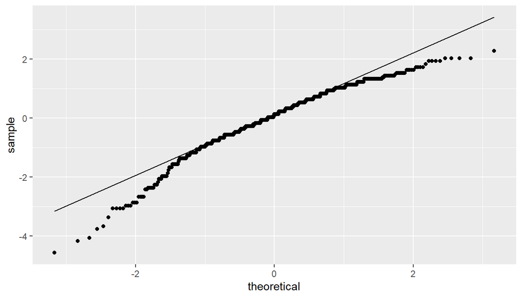

```r
ggplot(data = best_actress_win_lm, aes(sample = .resid)) + stat_qq() + stat_qq_line()
```

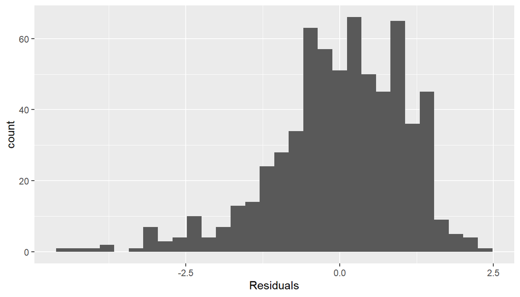

```r
ggplot(data = best_actress_win_lm, aes(x = .resid)) +
  geom_histogram() +
  xlab("Residuals")
```

Summary of this linear model shows a low adjusted R square. The residual distribution is nearly normal around zero but it lacks constant variance. From this we can see a very weak linear relation between these two variables.

**(7)** we examine relations between imdb_ratings and best_dir_win.

```r
best_dir_win_lm <- lm(formula = imdb_rating ~ best_dir_win, data = movies)

summary(best_dir_win_lm)
```

```
##
## Call:
## lm(formula = imdb_rating ~ best_dir_win, data = movies)
##
## Residuals:
##     Min      1Q  Median      3Q     Max
## -4.5543 -0.5543  0.0457  0.7519  2.0457
##
## Coefficients:
##                 Estimate Std. Error t value Pr(>|t|)
## (Intercept)      6.45428    0.04363 147.948  < 2e-16 ***
## best_dir_winyes  0.58758    0.16974   3.462 0.000572 ***
## ---
## Signif. codes:  0 '***' 0.001 '**' 0.01 '*' 0.05 '.' 0.1 ' ' 1
##
## Residual standard error: 1.076 on 649 degrees of freedom
## Multiple R-squared:  0.01813,    Adjusted R-squared:  0.01662
## F-statistic: 11.98 on 1 and 649 DF,  p-value: 0.0005722
```

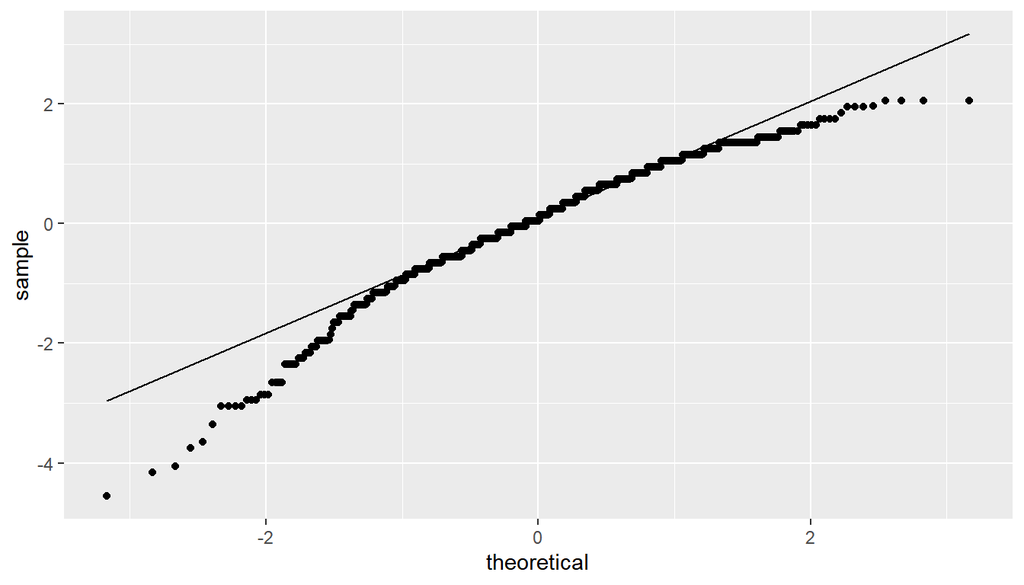

```r
ggplot(data = best_dir_win_lm, aes(sample = .resid)) + stat_qq() + stat_qq_line()
```

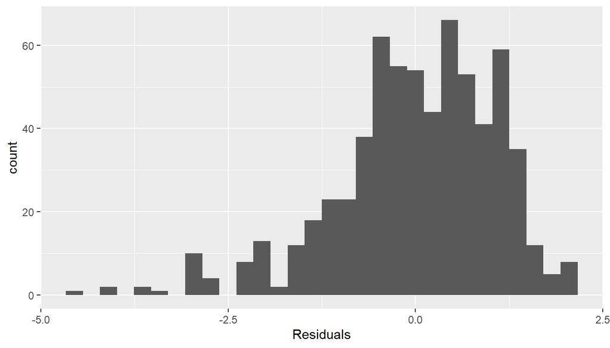

```r
ggplot(data = best_dir_win_lm, aes(x = .resid)) +
  geom_histogram() +
  xlab("Residuals")
```

Summary of this linear model shows a low adjusted R square. The residual distribution is nearly normal around zero but it lacks constant variance. From this we can see a very weak linear relation between these two variables.

**(8)** we examine relations between imdb_ratings and top200_box.

```r
top200_box_lm <- lm(formula = imdb_rating ~ top200_box, data = movies)

summary(top200_box_lm)
```

```
##
## Call:
## lm(formula = imdb_rating ~ top200_box, data = movies)
##
## Residuals:
##     Min      1Q  Median      3Q     Max
## -4.5778 -0.5778  0.1222  0.8222  2.5222
##
## Coefficients:
##               Estimate Std. Error t value Pr(>|t|)
## (Intercept)    6.47783    0.04286 151.122   <2e-16 ***
## top200_boxyes  0.66217    0.28239   2.345   0.0193 *
## ---
## Signif. codes:  0 '***' 0.001 '**' 0.01 '*' 0.05 '.' 0.1 ' ' 1
##
## Residual standard error: 1.081 on 649 degrees of freedom
## Multiple R-squared:  0.008401,   Adjusted R-squared:  0.006873
## F-statistic: 5.499 on 1 and 649 DF,  p-value: 0.01933
```

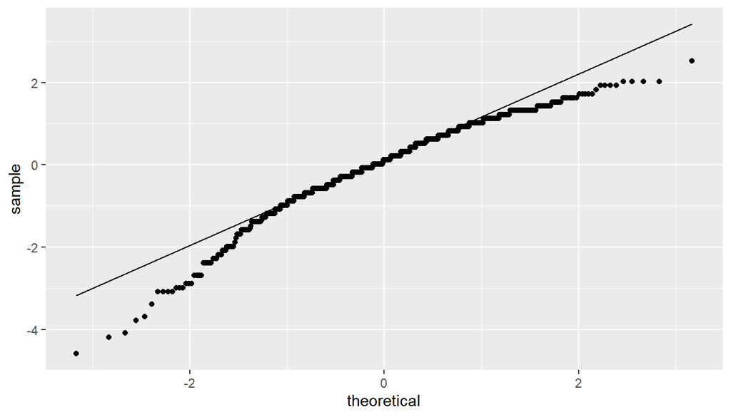

```r
ggplot(data = top200_box_lm, aes(sample = .resid)) + stat_qq() + stat_qq_line()
```

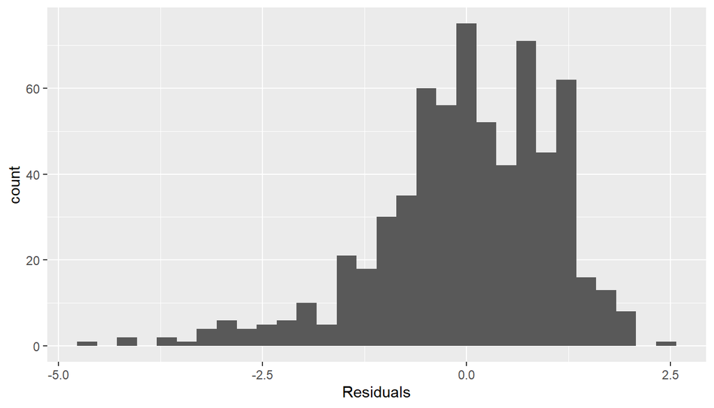

```r
ggplot(data = top200_box_lm, aes(x = .resid)) +
  geom_histogram() +
  xlab("Residuals")
```

Summary of this linear model shows a low adjusted R square. The residual distribution is nearly normal around zero but it lacks constant variance. From this we can see a weak linear relation between these two variables.

**(9)** we examine relations between imdb_ratings and director.

```r
director_lm <- lm(formula = imdb_rating ~ director, data = movies)

summary(director_lm)
```

```
##
## Call:
## lm(formula = imdb_rating ~ director, data = movies)
##
## Residuals:
##    Min     1Q Median     3Q    Max
## -1.933  0.000  0.000  0.000  1.900
##
## Coefficients:
##                                     Estimate Std. Error t value Pr(>|t|)
## (Intercept)                           2.1000     0.5352   3.924 0.000147 ***
## directorAbel Ferrara                  4.5000     0.9269   4.855 3.76e-06 ***
## directorAdam McKay                    4.2000     0.9269   4.531 1.42e-05 ***
## directorAdam Salky                    3.8000     0.9269   4.100 7.67e-05 ***
## directorAdam Shankman                 4.7000     0.9269   5.071 1.50e-06 ***
## directorAdam Simon                    1.3000     0.9269   1.403 0.163412
## directorAdrian Grenier                5.3000     0.9269   5.718 8.40e-08 ***
## directorAgnes Varda                   5.5000     0.9269   5.934 3.09e-08 ***
## directorAgnieszka Holland             4.8000     0.7568   6.342 4.42e-09 ***
## directorAlan Alda                     3.6000     0.7568   4.757 5.66e-06 ***
## directorAlejandro Agresti             4.7000     0.9269   5.071 1.50e-06 ***
## directorAlejandro Gonzalez Inarritu   5.6000     0.9269   6.042 1.86e-08 ***
## directorAlejandro Jodorowsky          5.6000     0.9269   6.042 1.86e-08 ***
## directorAlex Chandon                  3.2000     0.9269   3.452 0.000774 ***
## directorAlex Gregory                  4.1000     0.9269   4.423 2.19e-05 ***
## directorAlex Smith                    4.0000     0.9269   4.315 3.35e-05 ***
## directorAlexandre Aja                 4.1000     0.9269   4.423 2.19e-05 ***
## directorAlice Wu                      5.5000     0.9269   5.934 3.09e-08 ***
## directorAllan Arkush                  4.7000     0.9269   5.071 1.50e-06 ***
## directorAlonso Mayo                   5.2000     0.9269   5.610 1.38e-07 ***
## directorAmir Bar-Lev                  5.7000     0.9269   6.149 1.11e-08 ***
## directorAmy Heckerling                4.1000     0.9269   4.423 2.19e-05 ***
## directorAmy Holden Jones              3.6000     0.9269   3.884 0.000171 ***
## directorAndre Heller                  5.2000     0.9269   5.610 1.38e-07 ***
## directorAndrew Bergman                4.4000     0.9269   4.747 5.90e-06 ***
## directorAndrew Davis                  4.3000     0.9269   4.639 9.19e-06 ***
## directorAndrew Niccol                 4.0000     0.9269   4.315 3.35e-05 ***
## directorAndrew Solt                   5.8000     0.9269   6.257 6.65e-09 ***
## directorAndrew Traucki                3.7000     0.9269   3.992 0.000115 ***
## directorAndrew V. McLaglen            4.4500     0.7568   5.880 3.97e-08 ***
```

[output cut: 494 more lines]

```
## directorWilliam Sachs                 1.3000     0.9269   1.403 0.163412
## directorWilliam Shatner               3.3000     0.9269   3.560 0.000537 ***
## directorWim Wenders                   5.6000     0.9269   6.042 1.86e-08 ***
## directorWolfgang Reitherman           5.5000     0.9269   5.934 3.09e-08 ***
## directorWoody Allen                   5.5000     0.6554   8.391 1.27e-13 ***
## directorYoshiaki Kawajiri             5.7000     0.9269   6.149 1.11e-08 ***
## directorYurek Bogayevicz              3.4000     0.9269   3.668 0.000369 ***
## directorYves Simoneau                 3.3000     0.9269   3.560 0.000537 ***
## ---
## Signif. codes:  0 '***' 0.001 '**' 0.01 '*' 0.05 '.' 0.1 ' ' 1
##
## Residual standard error: 0.7568 on 117 degrees of freedom
##   (2 observations deleted due to missingness)
## Multiple R-squared:  0.9123, Adjusted R-squared:  0.5144
## F-statistic: 2.293 on 531 and 117 DF,  p-value: 9.522e-08
```

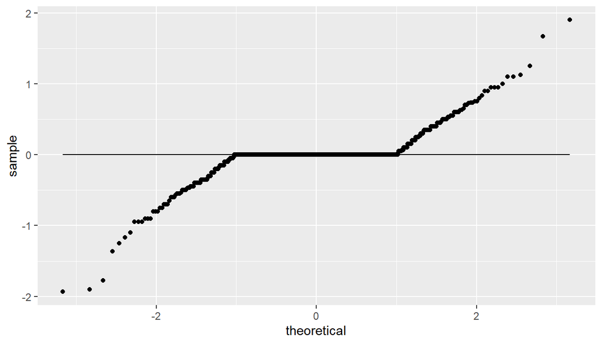

```r
ggplot(data = director_lm, aes(sample = .resid)) + stat_qq() + stat_qq_line()
```

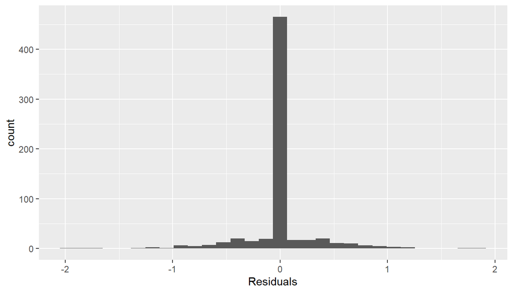

```r
ggplot(data = director_lm, aes(x = .resid)) +
  geom_histogram() +
  xlab("Residuals")
```

**(10)** we examine relations between imdb_ratings and genre.

```r
genre_lm <- lm(formula = imdb_rating ~ genre, data = movies)

summary(genre_lm)
```

```
##
## Call:
## lm(formula = imdb_rating ~ genre, data = movies)
##
## Residuals:
##     Min      1Q  Median      3Q     Max
## -3.9734 -0.4734  0.0552  0.6234  2.5203
##
## Coefficients:
##                                Estimate Std. Error t value Pr(>|t|)
## (Intercept)                     5.97077    0.11913  50.120  < 2e-16 ***
## genreAnimation                 -0.07077    0.34160  -0.207  0.83594
## genreArt House & International  0.64352    0.28299   2.274  0.02330 *
## genreComedy                    -0.22594    0.15746  -1.435  0.15181
## genreDocumentary                1.67731    0.17869   9.386  < 2e-16 ***
## genreDrama                      0.70267    0.13121   5.355 1.19e-07 ***
## genreHorror                    -0.20990    0.23302  -0.901  0.36805
## genreMusical & Performing Arts  1.32923    0.30177   4.405 1.24e-05 ***
## genreMystery & Suspense         0.50889    0.17270   2.947  0.00333 **
## genreOther                      0.66048    0.26804   2.464  0.01400 *
## genreScience Fiction & Fantasy -0.21521    0.34160  -0.630  0.52890
## ---
## Signif. codes:  0 '***' 0.001 '**' 0.01 '*' 0.05 '.' 0.1 ' ' 1
##
## Residual standard error: 0.9605 on 640 degrees of freedom
## Multiple R-squared:  0.2281, Adjusted R-squared:  0.216
## F-statistic: 18.91 on 10 and 640 DF,  p-value: < 2.2e-16
```

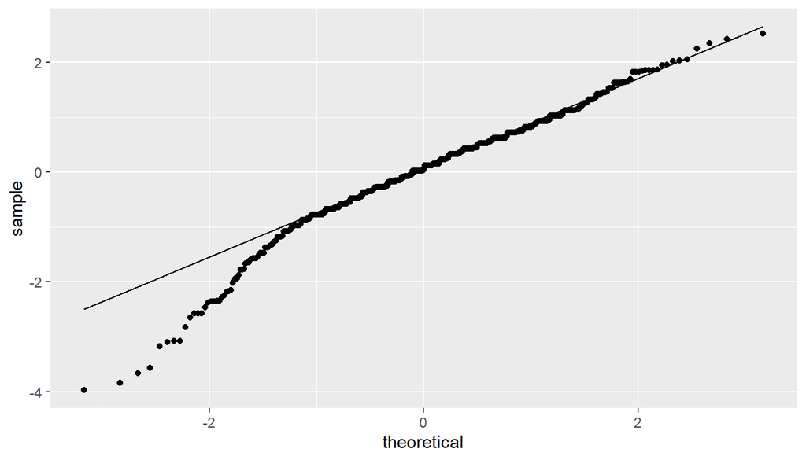

```r
ggplot(data = genre_lm, aes(sample = .resid)) + stat_qq() + stat_qq_line()
```

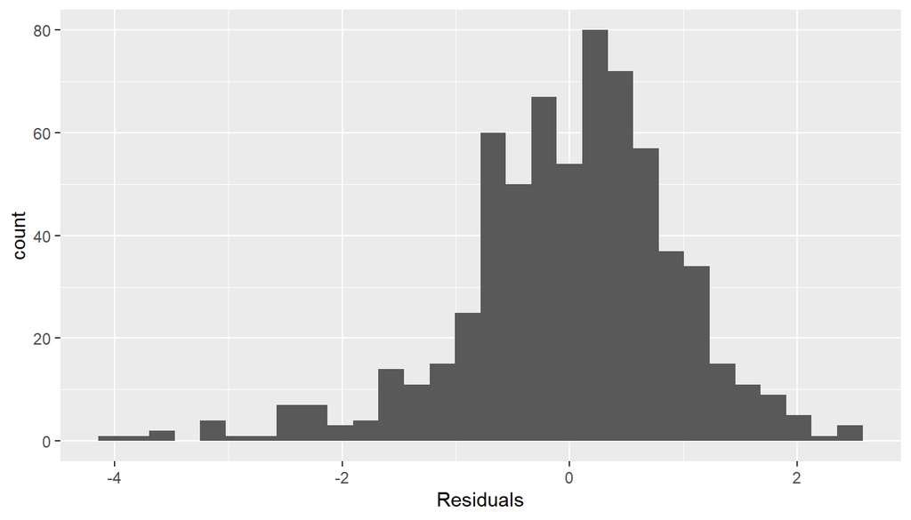

```r
ggplot(data = genre_lm, aes(x = .resid)) +
  geom_histogram() +
  xlab("Residuals")
```

**From our above exploration we can see genre, director, audience_score, critics_score, best_pic_win variables have a linear realtion with imdb_ratings.**

### Section B: **Co-linearity Check**

There is a co-linearity between audience_score and critics_score.

```r
cor(movies$audience_score,movies$critics_score)
```

```
## [1] 0.7042762
```

So we can not choose both. **Here I will take audience_score because it serves a better model.**

## Part 4: Modeling

Now I will use **backward elemination** on adjusted R squares to chose my model.

I have selected genre, director, audience_score, critics_score, best_pic_win variables for calculating model *parsimony*.

At first we will check adjusted R squares including all variales.

```r
m0 <- lm(formula = imdb_rating ~ director + genre + audience_score + best_pic_win, data = movies)

summary(m0)$adj.r.squared
```

```
## [1] 0.9002532
```

Now I will eleminate each variable and check the adjusted r square value for that model.

**model 1:** (eliminating genre)

```r
m1 <- lm(formula = imdb_rating ~ director + audience_score + best_pic_win, data = movies)

summary(m1)$adj.r.squared
```

```
## [1] 0.903747
```

**model 2:** (eliminating director)

```r
m2 <- lm(formula = imdb_rating ~ genre + audience_score + best_pic_win, data = movies)

summary(m2)$adj.r.squared
```

```
## [1] 0.7722839
```

**model 3:** (eliminating audience_score)

```r
m3 <- lm(formula = imdb_rating ~ genre + director + best_pic_win, data = movies)

summary(m3)$adj.r.squared
```

```
## [1] 0.5436623
```

**model 4:** (eliminating best_pic_win)

```r
m4 <- lm(formula = imdb_rating ~ director + audience_score + genre, data = movies)

summary(m4)$adj.r.squared
```

```
## [1] 0.9005378
```

At this point of our analysis model 1 has the most adjusted r square value. Now we will eliminate each variable from model 1 once and check adjusted r square.

**model 5:** (eliminating director from model 1)

```r
m5 <- lm(formula = imdb_rating ~  audience_score + best_pic_win, data = movies)

summary(m5)$adj.r.squared
```

```
## [1] 0.7485014
```

**model 6:** (eliminating audience_score from model 1)

```r
m6 <- lm(formula = imdb_rating ~  director + best_pic_win, data = movies)

summary(m6)$adj.r.squared
```

```
## [1] 0.5339287
```

```r
m7 <- lm(formula = imdb_rating ~  audience_score + director, data = movies)

summary(m7)$adj.r.squared
```

```
## [1] 0.9039949
```

Here we can see adjusted r square does increase in model 7 if we eliminate variable best_pic_win from model 1.

Thus **model 7** is my final selection.

###Model Dianostics##

My model depends on the following assumptions.

- The residuals of the model are nearly normal.
- The variablility of the residuals is nearly constant.

First let us see the histogram of the residual.

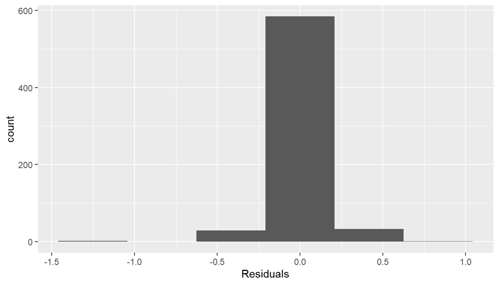

```r
m7 <- lm(formula = imdb_rating ~  audience_score + director, data = movies)

ggplot(data = m7, aes(x = .resid)) +
  geom_histogram(binwidth = 0.41684965465) +
  xlab("Residuals")
```

The distribution is nearly normal and centred around zero.

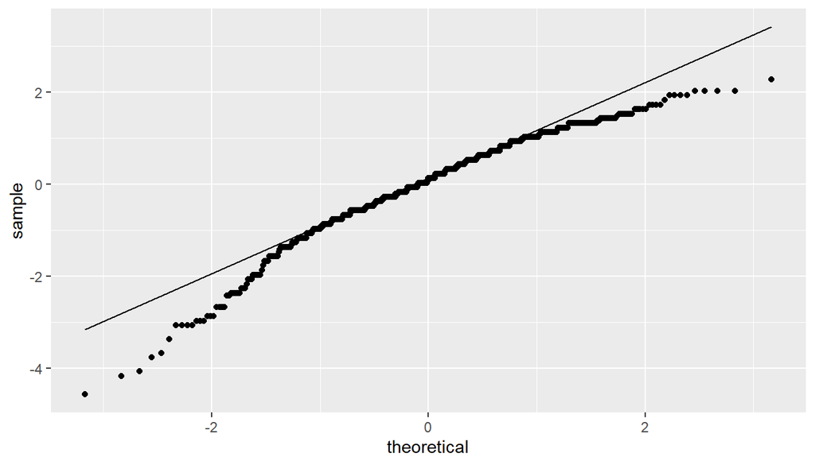

```r
ggplot(data = best_actress_win_lm, aes(sample = .resid)) + stat_qq() + stat_qq_line()
```

### Interpretations of the co-efficients

We can find the co-efficients of the model from summary. Here as we have used director as our model variable it has one co-efficient for each director.

It means if every other things held constant the imdb rating for a movie will change according to co-efficient related to its director. If the co-efficient is (+)ive then the rating will go up by *respective co-efficient*. Otherwise it goes down.

Similar case is for the audience score. If every other things held constant the imdb rating for a movie will go up by audience_score multiplied by the co-efficient.

## Part 5: Prediction

I Will use my linear model described above to predict the imdb ratings for the movie “Dunkirk”. For this prediction I will need the name of the director, audience score from rotten tomatoes. “Dunkirk” is an action film directed by Christoppher Nolan with an audience rating of 88%. My prediction for this film.

```r
new_movie <- data.frame(director = "Christopher Nolan", audience_score = 88)

predict(m7, new_movie, interval = "prediction", level = 0.95)
```

```
##       fit      lwr      upr
## 1 8.30471 7.488239 9.121181
```

From this we can say that we are 95% confident about the imdb ratings for the movie “Dunkirk” is **expected** to be in between 7.488239 and 9.121181.

My Multiple Linear Regression model shows the rating is *expected* to be 8.30471.

The actual imdb rating for this movie is 7.9. My findings is prettty close to the actual rating.

## Part 6: Conclusion

I tried every potential variables that can be a possible predictor of imdb rating. I explored their relationship with the ratings with the help linear modeling and plots. I also checked the colinearity between my most potential variables.

After that I used backward elimination to find out the best model for my question.

##Thank you.